# OSCC RNA-seq analysis

**KEGG Term-Gene heatmap**

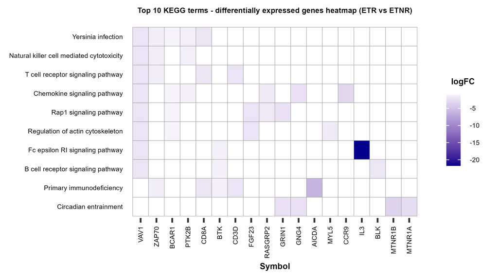

**KEGG Dot plot**

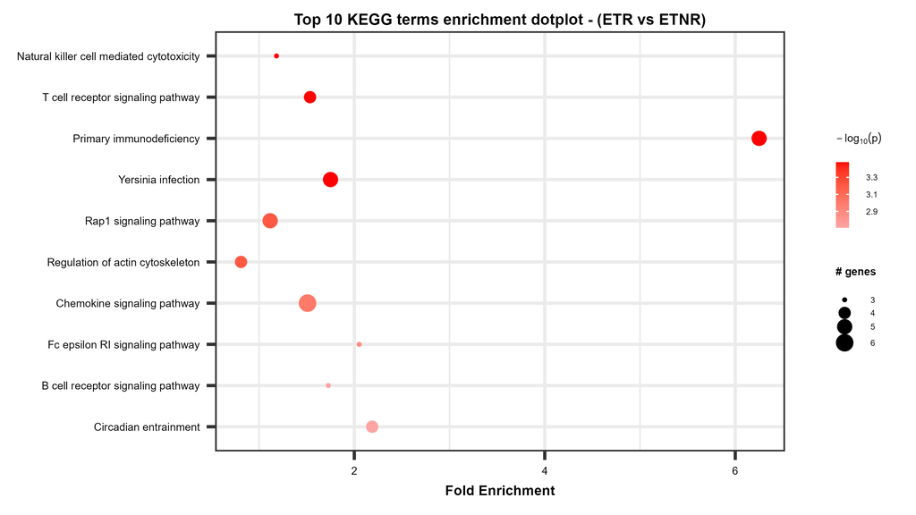

**KEGG Representative Dot plot**

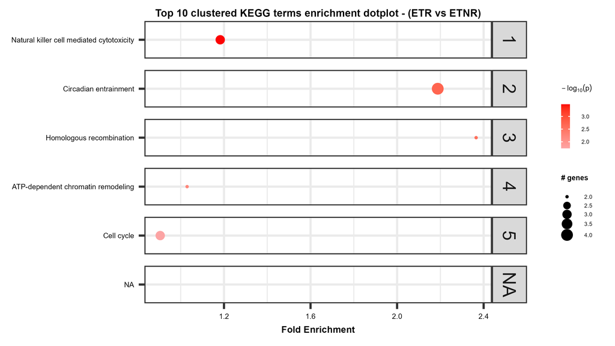

**BioCarta**

**BioCarta Term-Gene heatmap**

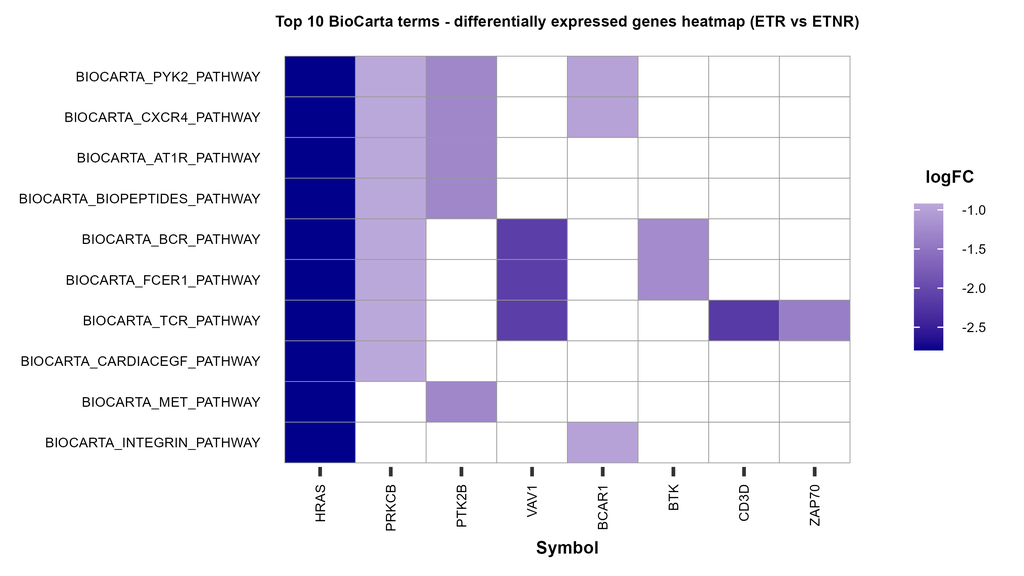

**BioCarta Dot plot**

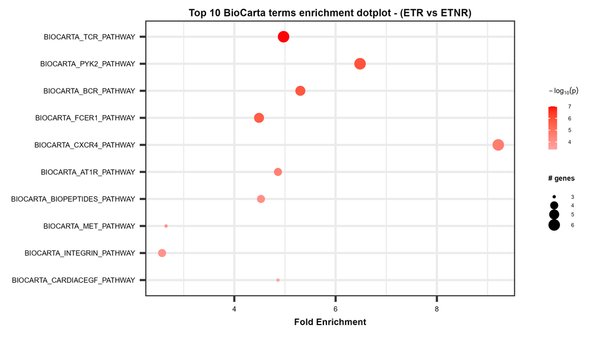

**BioCarta Representative Dot plot**

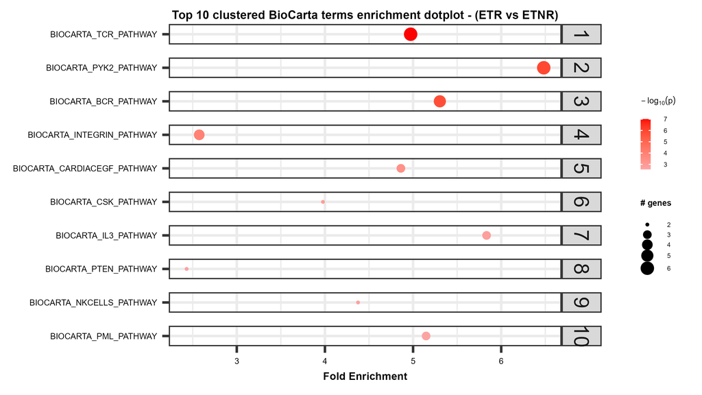

#### Recurrent Late-Stage Tumors vs. Non-Recurrent Late-Stage Tumors

**GO-BP**

**GO-BP Term-Gene heatmap**

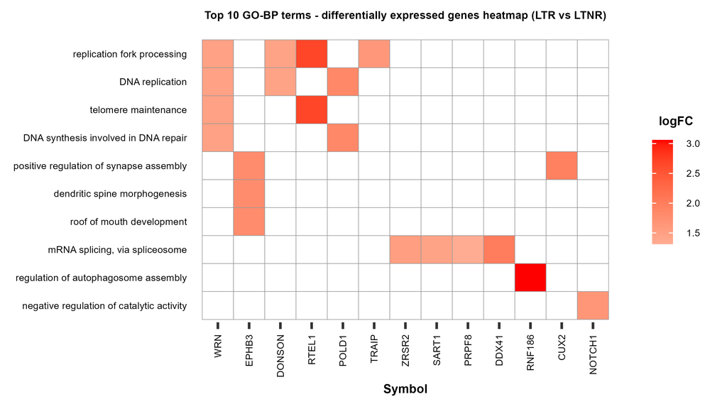

**GO-BP Dot plot**

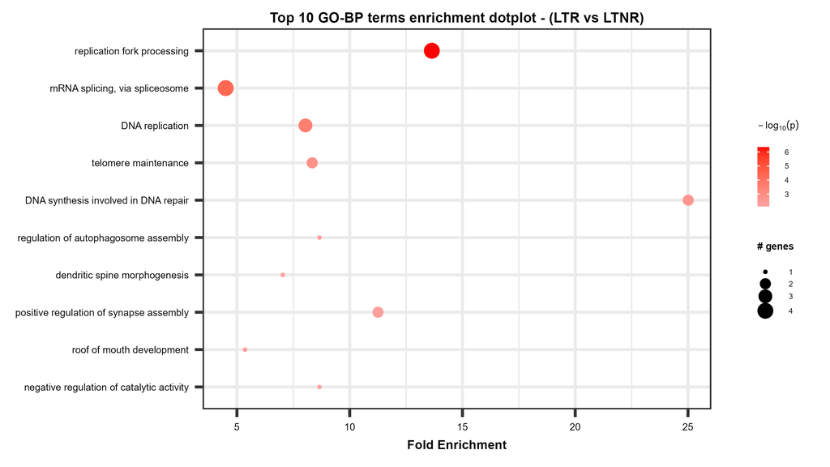

**GO-BP Representative Dot plot**

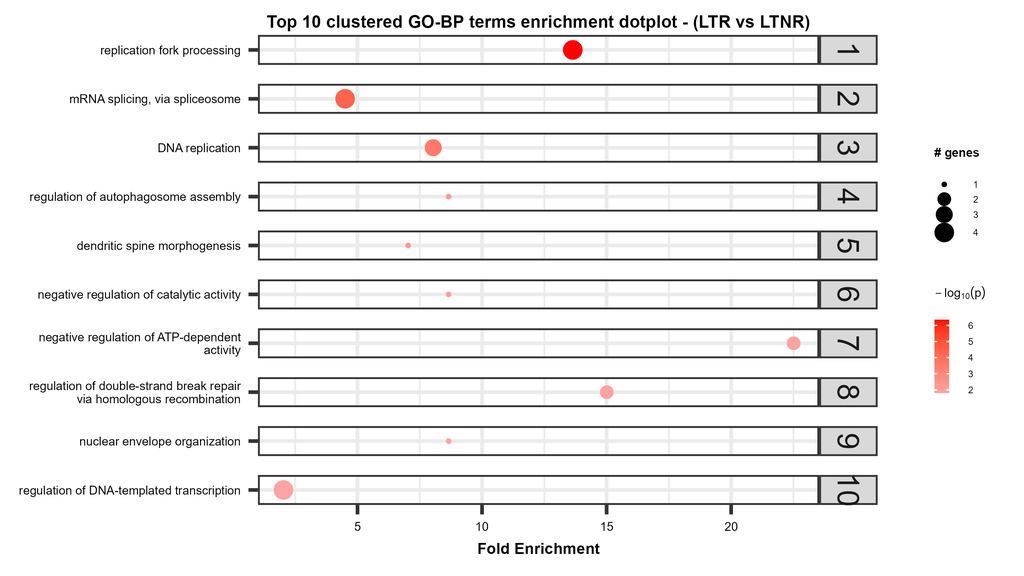

**GO-MF**

**GO-MF Term-Gene heatmap**

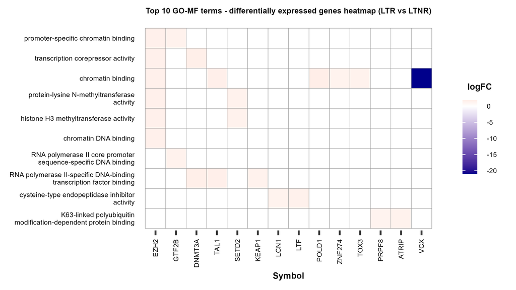

**GO-MF Dot plot**

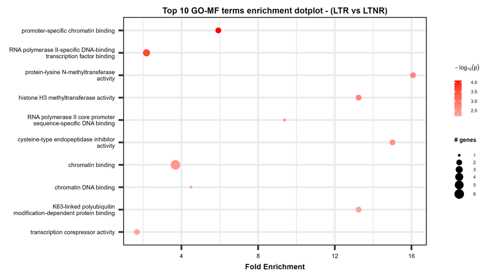

**GO-MF Representative Dot plot**

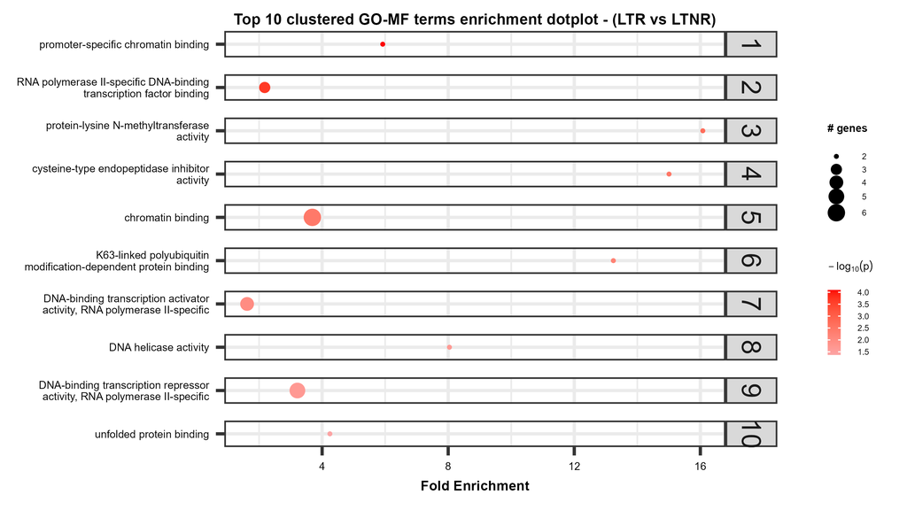

**GO-CC**

**GO-CC Term-Gene heatmap**

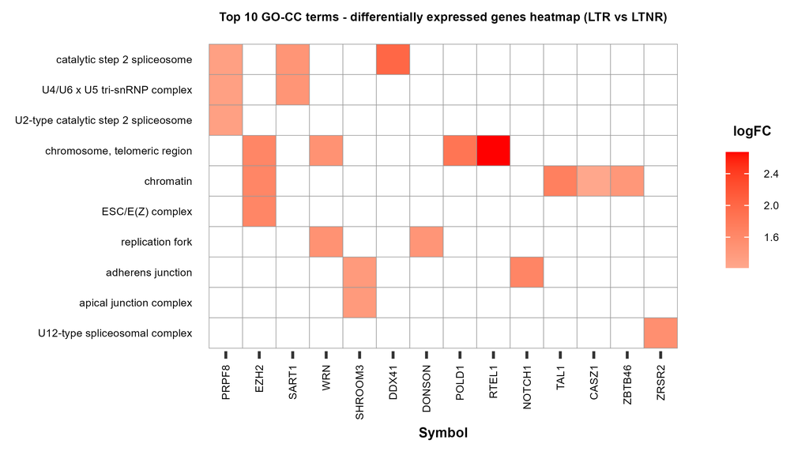

**GO-CC Dot plot**

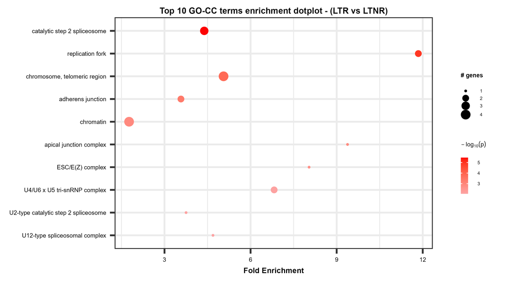

**GO-CC Representative Dot plot**

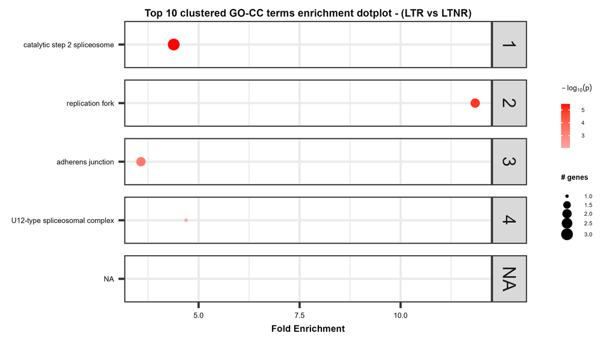

**Reactome**

**Reactome Term-Gene heatmap**

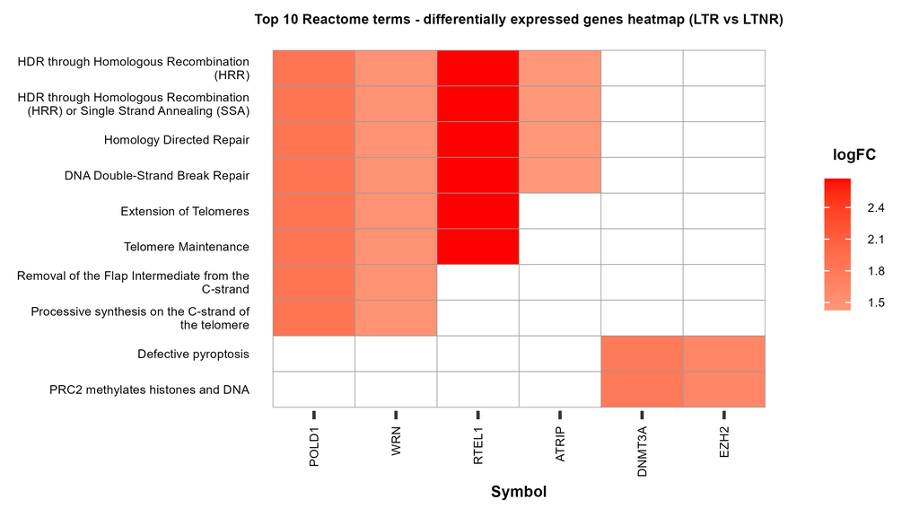

**Reactome Dot plot**

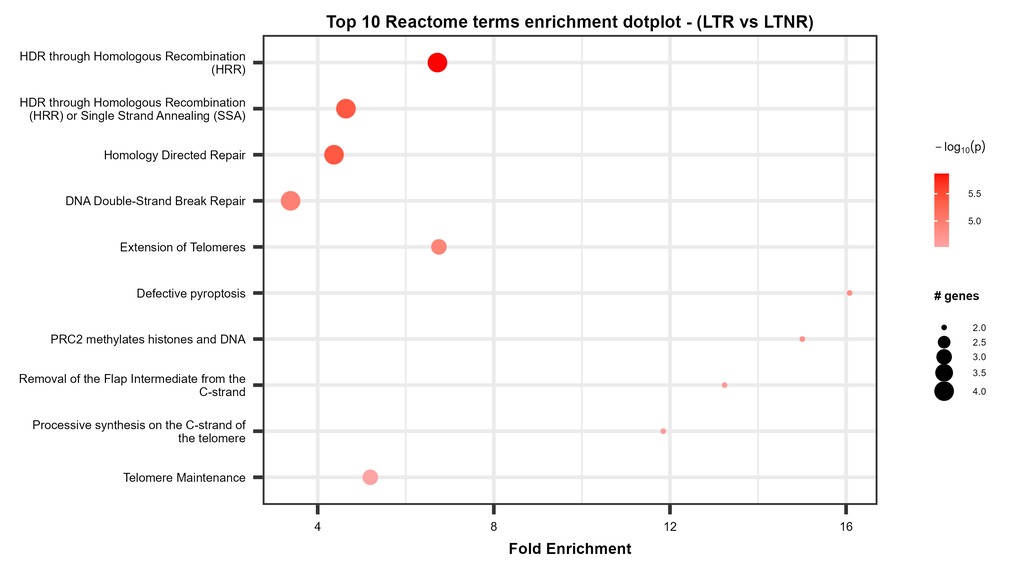

**Reactome Representative Dot plot**

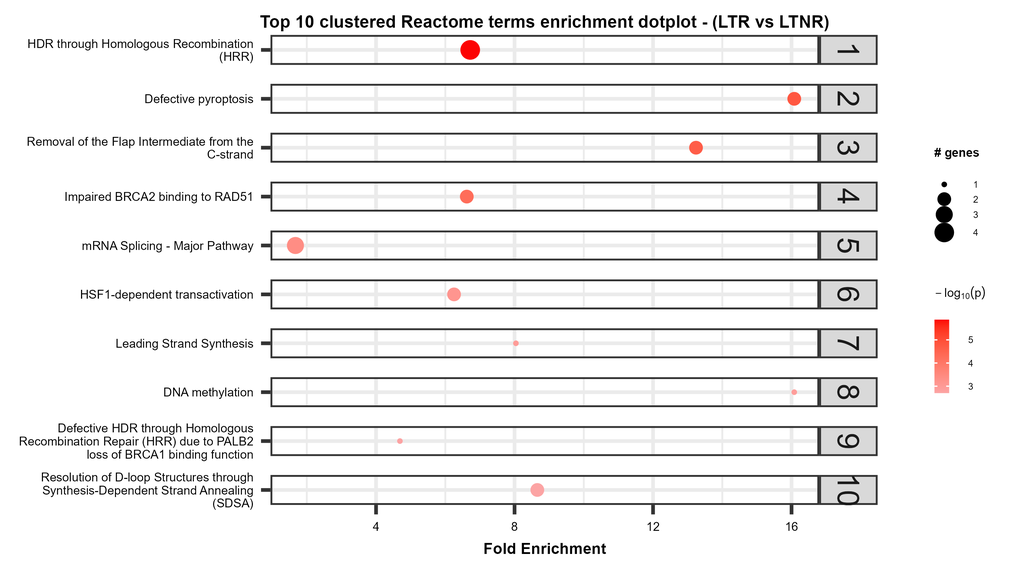

**KEGG**

**KEGG Term-Gene heatmap**

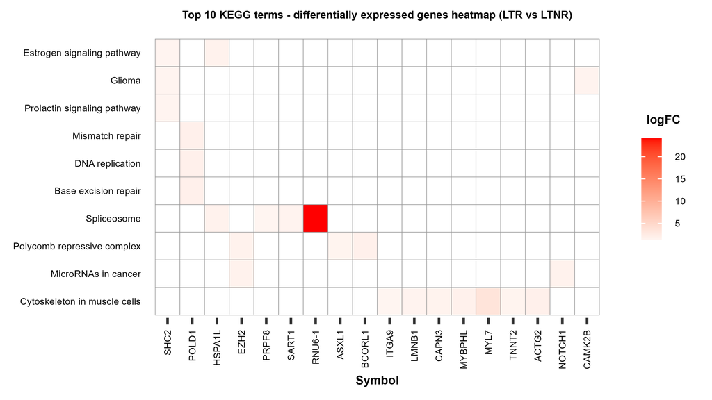

**KEGG Dot plot**

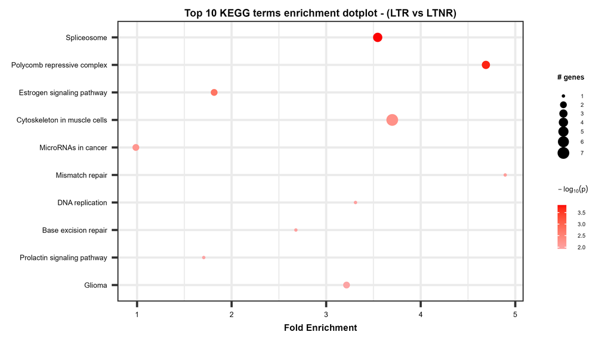

**KEGG Representative Dot plot**

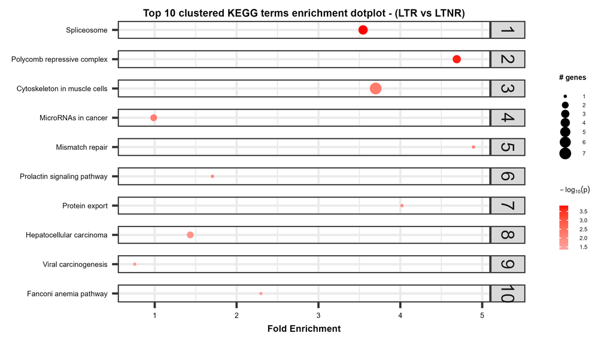

**BioCarta**

**BioCarta Term-Gene heatmap**

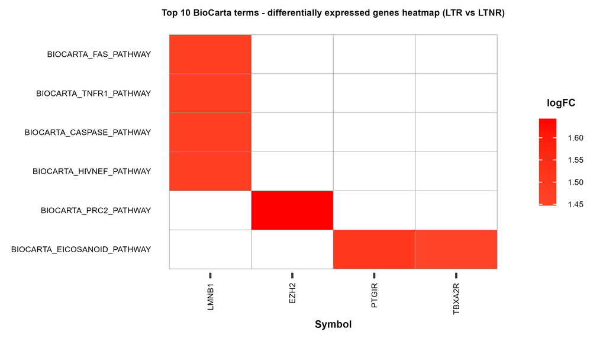

**BioCarta Dot plot**

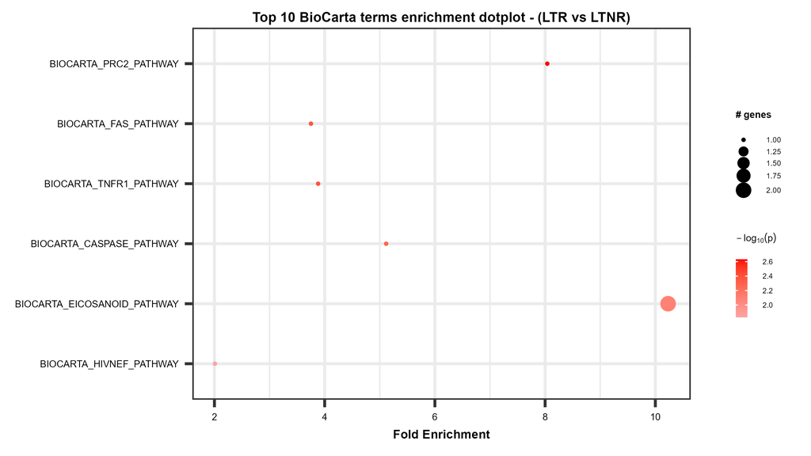

**BioCarta Representative Dot plot**

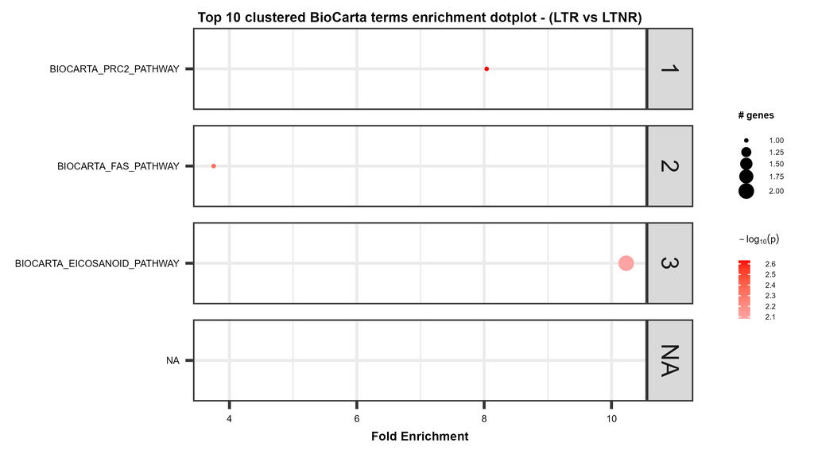